# Frontal cortex-driven glycinergic inhibition of the intralaminar thalamus

Viktor Plattner, Emilia Bosz, Laszlo Acsady

# 1 Firing rate of IL neurons during glycinergic fiber activation

In these experiments glycinergic fibers were photactivated while the firing rate of individual IL neurons was recorded. Some of the IL cells had very low baseline activity. In order to increase the firing rate of the IL neurons and to detect the effect of the glycinergic fiber activation a small tail pinch was applied. The firing rate of the recorded IL cells decreased during the glycinergic fiber activation.

## 1.1 Loading data

Loading AP and stimuli times from *stimulus* and from *baseline* data to **IL_stim_firing** and to **IL_baseline_firing** tables:

```r
IL_stim_firing <- CreateRecTibble(AP_times = read_csv(file.path("data",
    "IL_MFR", "stimulus", "AP_times.csv")),
    stim_times = read_csv(file.path("data",
        "IL_MFR", "stimulus", "stim_times.csv")))
IL_stim_firing %>% head()
```

[output not shown]

```r
IL_baseline_firing <- CreateRecTibble(
  AP_times = read_csv(file.path("data", "IL_MFR", "baseline", "AP_times.csv")),
  stim_times = read_csv(file.path("data", "IL_MFR", "baseline", "stim_times.csv"))
)
IL_stim_firing %>% head()
```

## 1.2 Summary information

Summary information of the *stimulus* and *baseline* recording files:

- Variables:
  - file names (*file_name*)
  - number of channels in the raw recording files (*No_ch*)
  - number of APs (*No_AP_unit*, *No_AP_unit2*)
  - number of stimulus trains (*No_Stim*)
  - LFP sampling rate (*samp_rate_lfp*)
  - unit sampling rate (*samp_rate_unit*)
  - length of the recording (*rec_length*)
  - length of the stimulus trains (*No_trains*)
  - Are the lengths of the stimulus trains equal in the recording (*train_length_equal*)
  - starting time of the stimulus trains (*train_start*)
  - ending time of the stimulus trains (*train_end*)

**CELL_INFO** table to store the cell categories. It was created manually using the information from the summary excel table (*Glicy_juxta-fm_exp_records_injection_sum.xls*)

- Variables
  - cell identification (*cell_id*). To find the recording file use the summary excel table
  - file names (*file_name*)
  - spontaneously active cells (*bl_activity*)
  - induced firing (*pinch*)
  - individually identified neurons (*ident*)
  - control cells (*control*)

## 1.3 Calculations

### 1.3.1 Firing rates

**b_d_a_MFR**: Calculating the number of APs -using a custom made function (*BDACalculator*)- before during and after the stimulus trains (*b_d_a_MFR*).

```r
b_d_a_MFR <- lapply(CELL_INFO$cell_id, BDACalculator, data = IL_stim_firing) %>%
  bind_rows() %>%
  dplyr::mutate(FR = No_AP / train_length) %>%
  dplyr::group_by(stim_cond, cell_id) %>%
  dplyr::summarise(MFR = mean(FR))
```

**sd_mean_isi**: Calculating the baseline MFR of the recorded IL cells from the *IL_baseline_firing* table using a custom made function (*SDMeanISI*). The results are stored in the *sd_mean_isi* table.

### 1.3.2 Ranks (strength of inhibition)

**cellranks**: Calculating ranks based on the activity change from “*baseline*” to “*during stimulus*”. If the activity change is negative (decreased MFR) the asigned rank is negative, if it is positive (increased MFR) the assigned rank is positive.

Calculating the firing rate change during stimulus (photoactivation of the glycinergic fibers) compared to baseline:

$$\mathbf{activity\_change} = \frac{during\_MFR - base\_MFR}{base\_MFR} * 100$$

```r
cellranks <- b_d_a_MFR %>%
  dplyr::group_by(stim_cond) %>%
  dplyr::mutate(base_MFR = sd_mean_isi$MFR) %>%
  dplyr::mutate(activity_change = ((MFR - base_MFR) / base_MFR * 100) %>% round(2)) %>%
  dplyr::filter(stim_cond == "d") %>%
  dplyr::mutate(change_rank = ifelse(activity_change > 0,
    rank(activity_change),
    -rank(-activity_change)
  )) %>%
  ungroup() %>%
  left_join(CELL_INFO %>%
    select(cell_id, control, pinch, position),
  by = "cell_id"
  )
cellranks
```

[output not shown]

**cellranks_before_stim**: Calculating ranks based on the activity change from “*before stimulus*” to “*during stimulus*”. If the activity change is negative (decreased MFR) the asigned rank is negative, if it is positive (increased MFR) the assigned rank is positive.

Calculating the firing rate change during stimulus (photoactivation of the glycinergic fibers) compared to before stimulus:

$$\mathbf{activity\_change} = \frac{during\_MFR - before\_MFR}{before\_MFR} * 100$$

```r
cellranks_before_stim <- b_d_a_MFR %>%
  spread(key = stim_cond, value = MFR) %>%
  dplyr::mutate(activity_change = ((d - b) / b * 100) %>% round(2)) %>%
  dplyr::mutate(change_rank = ifelse(activity_change > 0,
    rank(activity_change),
    -rank(-activity_change)
  )) %>%
  left_join(CELL_INFO %>%
    select(cell_id, control, pinch, position),
  by = "cell_id"
  )
cellranks_before_stim
```

### 1.3.3 Data to plot

**TO_PLOT**: Combining *b_d_a_MFR* (firing rate of 29 IL neurons b/d/a stim) with *sd_mean_isi* table (baseline firing rate of the same 29 neurons), joining with CELL_INFO containing important information of the cells (baseline activity, identified, pinched, control) and with *cellranks* containing the ranks asigned to each cells based on the changes in MFR during the stimulus compared to baseline.

```r
TO_PLOT <- bind_rows(
  sd_mean_isi %>%
    select(MFR, cell_id, stim_cond),
  b_d_a_MFR
) %>%
  left_join(CELL_INFO %>%
    select(-file_name),
  by = "cell_id"
  ) %>%
  left_join(cellranks %>%
    select(cell_id, change_rank, activity_change),
  by = "cell_id"
  )

datatable(TO_PLOT,
  caption = "TO_PLOT table",
  rownames = TRUE,
  options = list(pageLength = 50, scrollX = T, scrollY = "500px", dom = "t")
)
```

## 1.4 Plotting

### 1.4.2 MFR before, during and after stimulus

### 1.4.3 Strength of inhibition

Firing rate change **during** stimulus (photoactivation of the glycinergic fibers) compared to **baseline**:

Firing rate change **during** stimulus (photoactivation of the glycinergic fibers) compared to **before** stimulus:

# 2 Activity of PRF glycinergic cells during PFC photoactivation

## 2.1 Loading and transforming (hidden code) data

```r
source(file.path("supplementary_functions", "CreateRecTibble.R"))
RECORDINGS <- CreateRecTibble(
  AP_times = read_csv(file.path("data", "cortical_stim", "AP_times.csv")),
  stim_times = read_csv(file.path("data", "cortical_stim", "stim_times.csv"))
)


### CAREFUL WITH THIS!! It's generated by the "CreatePSTHTibble" function but the frequencies have to be changed manually, and it can create duplicates! I have to work on that!
STIM_RESULTS <- read_csv(file.path("output_data", "cortical_stim_analysis.csv"))
```

- List of tibbles used to store data:
  - RECORDINGS tibble: stores AP and stim time stamps, number of stimuli in each train, stimulus frequency categories (eg. 8 10 and 12 Hz belong to 10 Hz category)
  - STIM_RESULTS: stores the data for PSTHs (CAREFUL WITH THIS!! It’s generated by the “CreatePSTHTibble” function but the frequencies have to be changed manually, and it can create duplicates! I have to work on that! If something doesn’t look right on PSTHs or response probability plots, check this one first)
  - hist_stats: stores PSTH statistics calculated from ggplot
  - RESP_PROB: response probability and latency data calculated from stim results and recordings
  - APC: number of APs after each stimulus in a 50 ms window

## 2.2 Plotting

### 2.2.1 Distribution of frist APs after cortical activation

### 2.2.2 PSTH @ 1 Hz cortical activation

### 2.2.3 PSTH @ 10 Hz cortical activation

### 2.2.4 PSTH @ 20 Hz cortical activation

### 2.2.5 Response probability and latency

### 2.2.6 Number of APs after each stimulus in stimulus trains (50 ms window)

# 3 Spontaneous desynchronization of the FC slow oscillation

## 3.1 Loading data

Loading mat files to *file_list* object

Example file: **08_right_PnO_t5_4083_baseline1_wake.mat"**

Content of mat files:

- AP channel
  - **title:** channel name
  - **comment:** notes about the channel
  - **resolution:** 2.5e-06
  - **interval:** time between two data points in sec (5e-05)
  - **scale:** scaling factor (y scale), real = (data * scale) + offset
  - **offset:** scale offset
  - **units:** unit of the channel (volt)
  - **length:** number of APs
  - **items:** No. points easch AP is represented by
  - **trigger:**
  - **traces:**
  - **times:** times of the APs (first data point of the waveform)
  - **codes:** marker codes of the APs
  - **values:** matrix containing the waveforms of the APs (described by a given No. points)
- EEG channel
  - **title:** channel name
  - **comment:**
  - **interval:**
  - **scale:** scaling factor (y scale), real = (data * scale) + offset
  - **offset:** scale offset
  - **units:**
  - **start:**
  - **length:**
  - **values:**

```r
file_to_load <- file_list[[1]]
filename <- as.character(substring(file_to_load, 1, nchar(file_to_load) - 4))
raw.rec <- readMat(file.path("data", file_to_load))

### takes the first AP (first row) and tells the index of point with the max value
points_to_peak <- which(raw.rec$ap[, , 1]$values[1, ] ==
  max(raw.rec$ap[, , 1]$values[1, ])) %>%
  as.numeric()

### time of the peak of the APs after its first point
raw.rec$ap[, , 1]$interval * points_to_peak

ap <- raw.rec$ap[, , 1]$times %>% as.double()
ap_peaks <- tibble(peak_times = (ap + c(raw.rec$ap[, , 1]$interval * points_to_peak)))
```

Loading all data calculated by **SyncDesyncAnalysis** function

## 3.2 Plotting

### 3.2.1 ISI to determine clusters

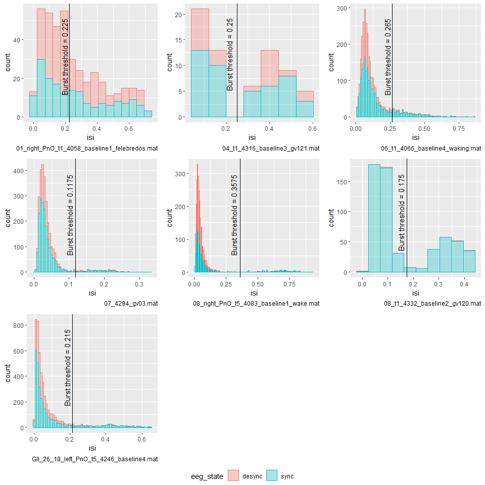

### 3.2.2 LFP and APs

### 3.2.3 Number of clusters in sync vs desync periods

# 4 Terminals

## 4.1 Loading data

```r
file_path <- file.path("data",
    "Emi_terminals", "terminal_measures.csv")
TERMINALS <- read.table(file = file_path,
    sep = ";", header = T, na.string = "na")
head(TERMINALS)
```

[output not shown]

## 4.2 Bouton area on different dendritic domains

## 4.3 Area of boutons with *m2* and *unknown* origin